# Exercício 2 da Aula 11 - Mapeamento de Múltiplos Intervalos

Alunos: Felipe Maniero Nazato, Diane Simon Rozzetto e Marisângela Rodrigues Santos

25/06/2015

# 1 Considere novamente o conjunto de dados de Mimulus e o caráter fenotípico que você escolheu em exercícios anteriores.

- Faça agora uma análise usando o MIM para localizar QTLs e estudar eventuais interações epistáticas entre eles, usando o R/qtl;
- Compare os resultados com o que foi obtido com o CIM, ressaltando as possíveis vantagens do MIM;
- Apresente os resultados em gráficos e tabelas com os QTLs mapeados, incluindo todas as informações que julgar importantes (LOD, efeitos, R2, etc);
- Explique como realizou a análise em detalhes, com um texto que poderia ser usado em Material e Métodos numa eventual publicação (texto em inglês);
- Apresente os resultados em um arquivo html;
- O exercício pode ser feito pelo mesmo grupo que já trabalhou nos dados de Mimulus.

## 1.1 Mapa genético MIMULUS

Em um exercício anterior, foi obtido o mapa genético para o conjunto de dados do MIMULUS.

O mapa do MIMULUS é composto por 14 grupos de ligação e pode ser observado na Figura abaixo:

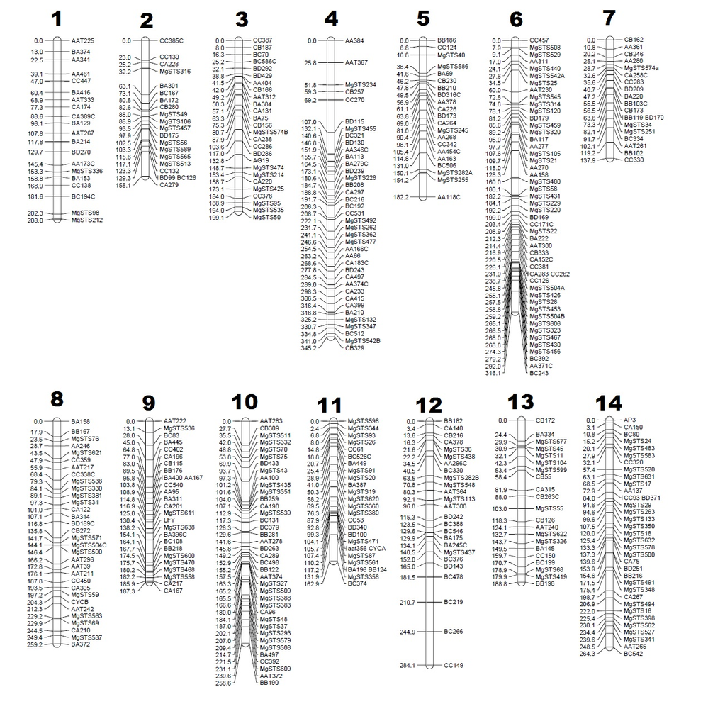

## 1.2 Entrada dos dados no R/qtl

De posse do mapa genético e do conjunto de dados completos do MIMULUS foi possível entrar com os dados no programa R/qtl da seguinte maneira:

- Mudar o diretório do R para a pasta onde foi salvo o arquivo do mapa e o arquivo completo do MIMULUS

```r
setwd("C:/Users/Felipe/Dropbox/Disciplinas/Biometria_de_marcadores_geneticos/aula_11")
```

- Requerer o “pacote” R/qtl

```r
library("qtl")
```

- Carregar os arquivos contendo o conjunto completo dos dados (**m_feb06.raw**) e o arquivo contendo o mapa genético (**mimulus_mapa_final.txt**):

$OBS_1$: O arquivo original do mimulus está salvo em **.raw** (contém dados genotípicos e fenotípicos)

$OBS_2$: Seguinto o tutorial do R/qtl foi possível identificar que o programa reconhece arquivos **.txt** exportados do OneMap. O mapa genético do conjunto de dados MIMULUS foi obtido pelo programa OneMap e exportado através da função **write.map(mapa, “mimulus_mapa_final”)**. A saída foi salva em um arquivo **.txt** contendo o mapa final do MIMULUS (arquivo **mimulus_mapa_final.txt**).

$OBS_3$: para abrir os arquivos no R/qtl, foi utilizado a função **read.cross** e o formato MapMaker (**“mm”**).

```r
dados_mimulus = read.cross("mm", file="m_feb06.raw", mapfile = "mimulus_mapa_final.txt")
```

```
##  --Read the following data:
##  Type of cross:          f2
##  Number of individuals:  287
##  Number of markers:      418
##  Number of phenotypes:   16
```

```
##  --Cross type: f2
```

- Como haviam marcadores sobrepostos uma mesma posição no cromossomo, foi utilizado a função **jittermap** (segundo o tutorial do R/qtl) para o ajuste.

```r
mimulus = jittermap(dados_mimulus)
```

- Após o carregamento, é possível observar um resumo dos dados do MIMULUS

```r
#Resumo dos dados
summary(mimulus)
```

```
##     F2 intercross
##
##     No. individuals:    287
##
##     No. phenotypes:     16
##     Percent phenotyped: 96.2 93.4 96.2 93 95.8 87.8 96.2 95.8 96.2 96.2
##                         90.2 96.2 95.8 96.2 95.8 96.2
##
##     No. chromosomes:    14
##         Autosomes:      1 2 3 4 5 6 7 8 9 10 11 12 13 14
##
##     Total markers:      377
##     No. markers:        20 20 26 38 21 49 19 32 26 38 26 25 21 16
##     Percent genotyped:  89.6
##     Genotypes (%):      AA:15.4  AB:24.3  BB:23.0  not BB:20.5  not AA:16.8
```

De acordo com o resumo dos dados, pode-se verificar que na população estudada (população $F_2$) existem 287 indivíduos, 377 marcadores (418 no total, no entanto o mapa final foi construido com 377 marcadores) e 16 características fenotípicas.

- Mapa genético (versão R/qtl)

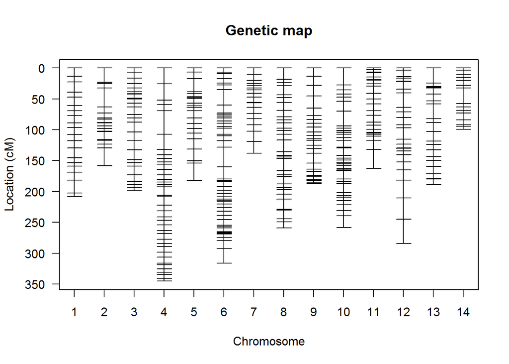

```r
#Mapa genético Mimulus
plot.map(mimulus)
```

- Para observar cada uma das características fenotípicas, foram plotados os seguintes gráficos:

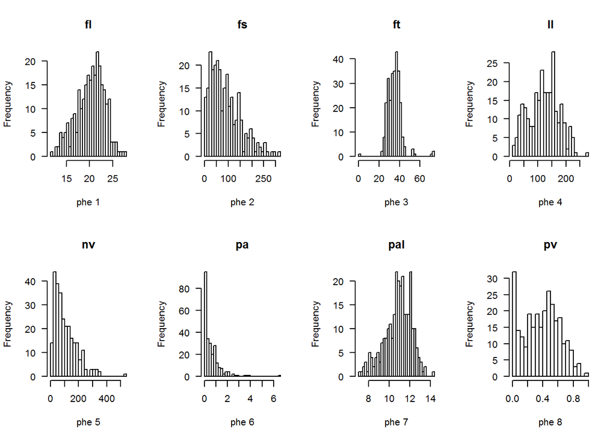

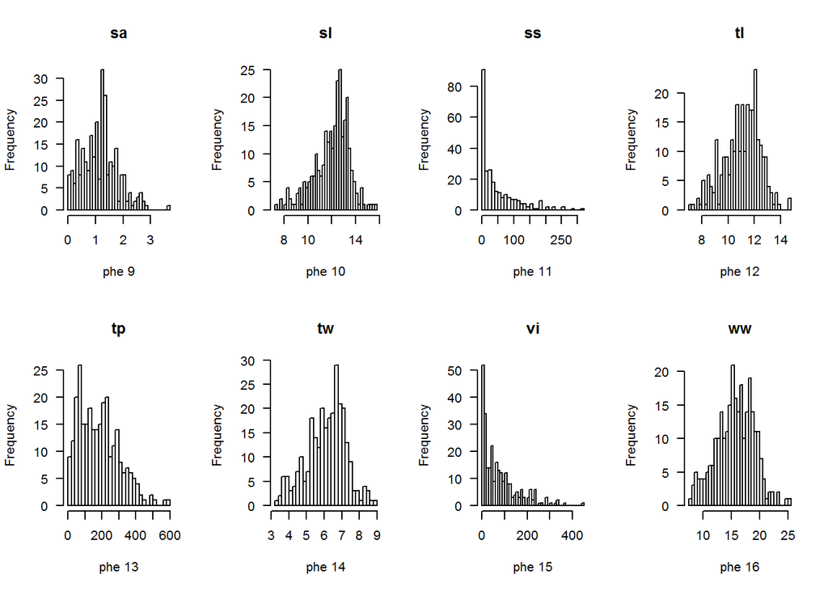

```r
par(mfrow=c(2,4))
for(i in 1:16)
  plot.pheno(mimulus, pheno.col=i)
```

-Após conversar com o professor Augusto, ele nos permitiu trabalhar com mais uma característica além da escolhida em exercício anterior (lista 10). Dessa forma iremos trabalhar com a característica fenotípica **pa** (phe 6) e com a característica **fl** (phe 1).

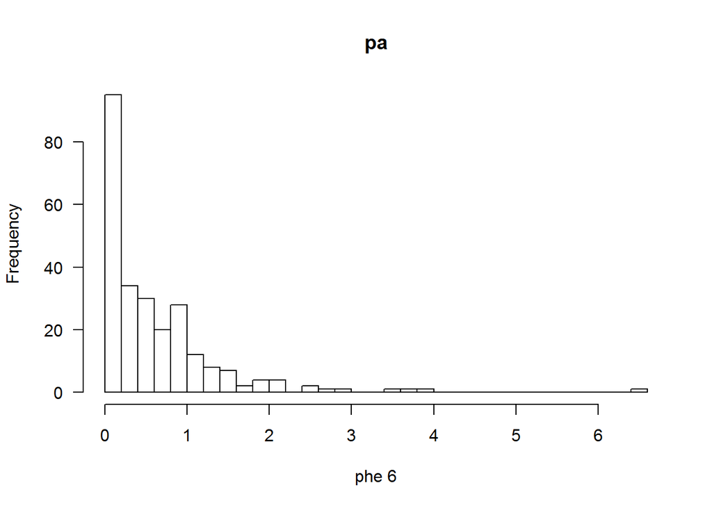

```r
plot.pheno(mimulus, pheno.col= 6)
```

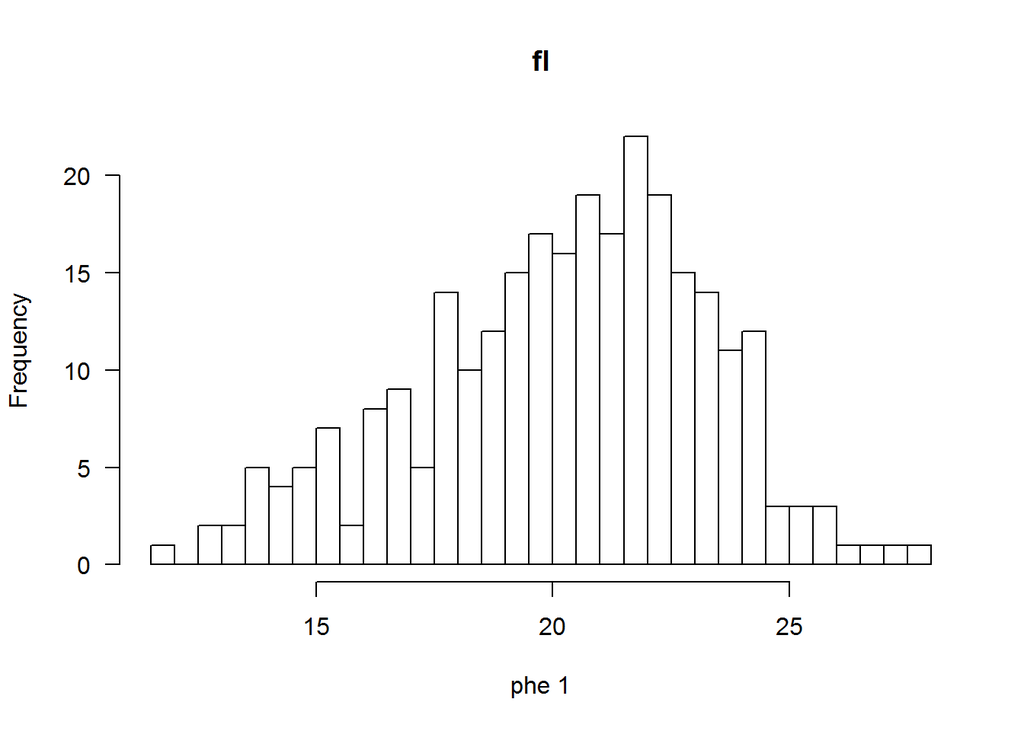

```r
plot.pheno(mimulus, pheno.col= 1)
```

## 1.3 Característica fenotípica phe 6 (pa)

### 1.3.1 Nível de significância (“Threshold”)

Primeiramente foi calculado o nível de significância (LOD) para declarar como significativo o efeito dos QTLs (“Threshold”).

Para isso, criou-se a distribuição de LODs sob $H_0$ utilizado os seguintes comandos:

$OBS_1$: foi utilizado a aproximação de Haley-Knott (“hk”) no cálculo das permutações;

$OBS_2$: foram realizadas 1000 permutações.

```r
#Significância - "uso de permutações"
mimulus_gp = calc.genoprob(mimulus, step = 10)
sig_perm = scanone(mimulus_gp, method = "hk", pheno.col=6, n.perm=1000)
```

```
## Doing permutation in batch mode ...
```

Foram obtidos os valores do threshold (LOD) para 5% (alpha) de significância:

```r
summary(sig_perm, alpha=c(0.05))
```

```
## LOD thresholds (1000 permutations)
##    lod
## 5% 3.9
```

E o gráfico da distribuição da estastística (LOD) sob $H_0$:

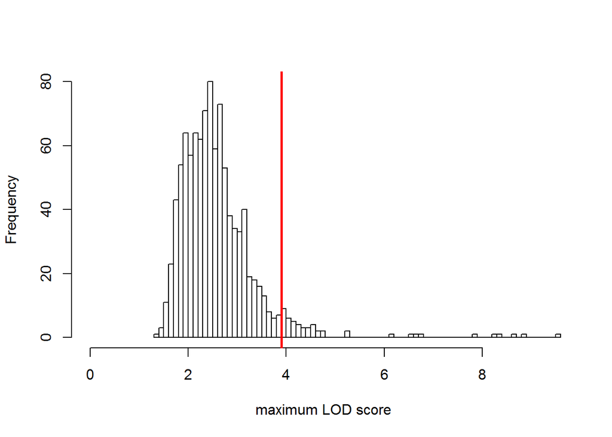

```r
plot(sig_perm)
abline(v=3.9, col="red", lwd=2.5)
```

### 1.3.2 Mapeamento por intervalo composto (CIM)

O mapeamento por intervalo composto pode ser realizado de acordo com os comando abaixo:

$OBS_1$: foi utilizado o algoritmo **“EM”**;

$OBS_2$: foi utilizado uma **window size = 10 cM**;

$OBS_3$: foi utilizado um **threshold = 3,9** (cálculo por permutação)

```r
# Mapeamento - intervalo composto (CIM)
mimulus_cim = cim(mimulus_gp, pheno.col=6, window=10, method = "em", n.marcovar=1)
summary(mimulus_cim)
```

```
##           chr   pos   lod
## AAT225      1   0.0 0.508
## MgSTS589    2 103.3 0.512
## c3.loc120   3 120.0 0.696
## c4.loc300   4 300.0 0.927
## c5.loc120   5 120.0 0.764
## c6.loc230   6 230.0 4.093
## c7.loc20    7  20.0 1.907
## MgSTS621    8  43.5 1.922
## BA445       9  45.0 1.470
## MgSTS539   10 112.9 1.470
## BA449      11  20.7 1.023
## AAT364     12  80.3 1.406
## MgSTS599   13  53.4 1.925
## MgSTS263   14  94.6 1.123
```

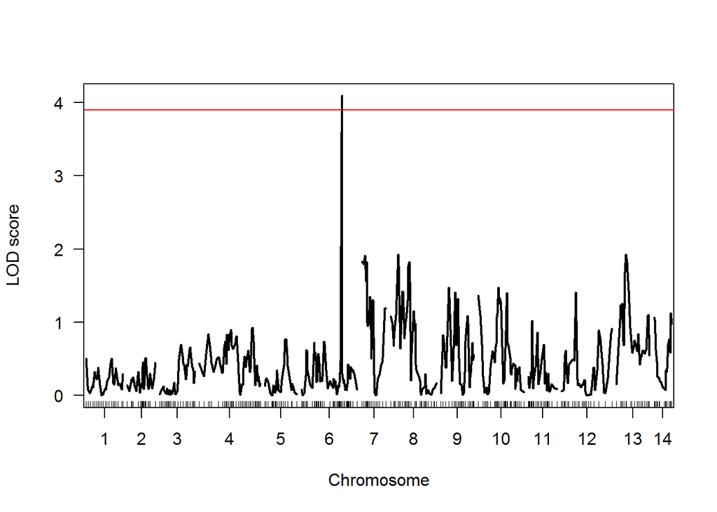

```r
plot(mimulus_cim, ylab="LOD score")
abline(h = 3.9, col="red") #5%
```

Pelos comandos abaixo é possível observar em detalhes o grupo de ligação 6:

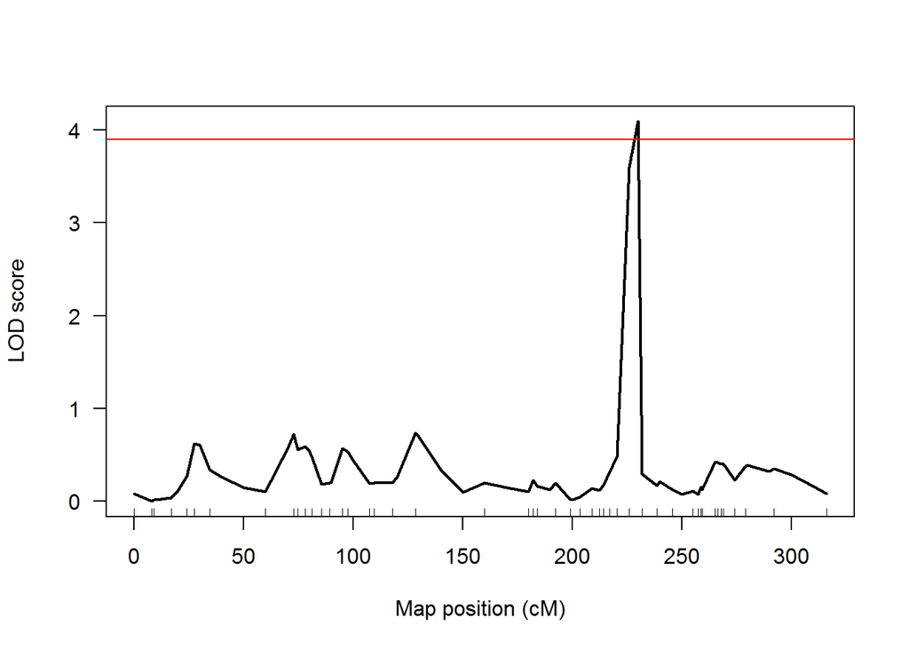

```r
plot(mimulus_cim, ylab="LOD score", chr=c(6))
abline(h = 3.9, col="red") #5%
```

Para encontrar os efeitos do QTL em questão, foi utilizado os seguintes comandos:

```r
#Efeito do QTL
mimulus_qtl_cim = makeqtl(mimulus_gp, chr=c(6), pos=c(231.9), what="prob")
qtl_cim_6 = fitqtl(mimulus_gp, qtl = mimulus_qtl_cim,
                  method="hk", pheno.col=6, get.ests=TRUE)
summary(qtl_cim_6)
```

```
##
##      fitqtl summary
##
## Method: Haley-Knott regression
## Model:  normal phenotype
## Number of observations : 252
##
## Full model result
## ----------------------------------
## Model formula: y ~ Q1
##
##        df        SS        MS      LOD     %var Pvalue(Chi2)    Pvalue(F)
## Model   2  10.92055 5.4602764 4.244194 7.462892 5.699098e-05 6.402244e-05
## Error 249 135.41082 0.5438186
## Total 251 146.33138
##
##
## Estimated effects:
## -----------------
##                 est        SE      t
## Intercept  0.625263  0.046873 13.340
## 6@231.9a  -0.305540  0.068688 -4.448
## 6@231.9d  -0.004202  0.094880 -0.044
```

```r
n=282
LOD1=3.973
r21=1-10^(((-2)/n)*LOD1)
r21
```

```
## [1] 0.06282068
```

#### 1.3.2.1 Resultado do CIM - fenótipo pa (phe 6)

Pelo método do mapeamento por intervalo composto (CIM) foi encontrado um QTL com efeito significativo sobre o fenótipo 6 (**pa**). O resultado do CIM foi resumido na Tabela abaixo (contendo o nome do QTL, o cromossomo que o contêm, a posição no cromossomo, o valor do intercepto da regressão, os valores dos efeito do QTL (aditivo e de dominância), o LOD e o $R^2$:

[output not shown]

E também no gráfico:

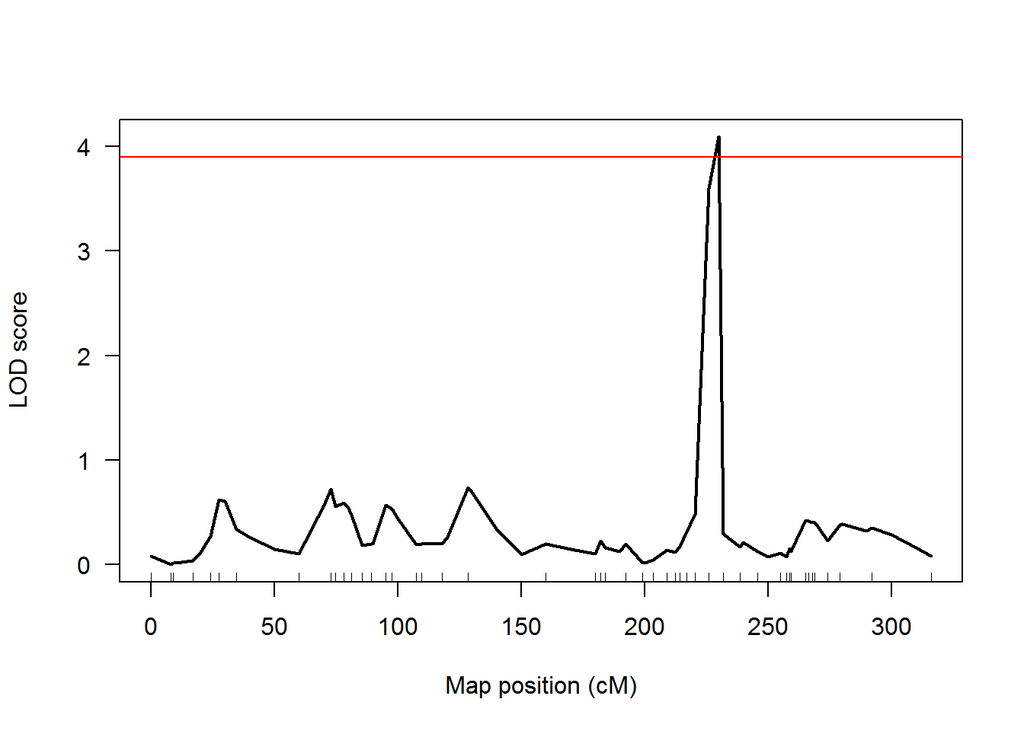

```r
plot(mimulus_cim, ylab="LOD score",chr=c(6))
abline(h = 3.9, col="red") #5%
```

### 1.3.3 Mapeamento por múltiplos intervalos - (MIM)

Primeiramente usou-se a função **scantwo** para escanear o genoma a procura de mais de um QTL.

```r
##Mapeamento - múltiplos intervalos (MIM)
mimulus_gp = calc.genoprob(mimulus, step = 5, error.prob=0.001)
mimulus_scan2 = scantwo(mimulus_gp,pheno.col=6, model="normal", method="hk",
                               use="all.obs", verbose=TRUE)
```

[output not shown]

[output cut: 52 more lines]

[output not shown]

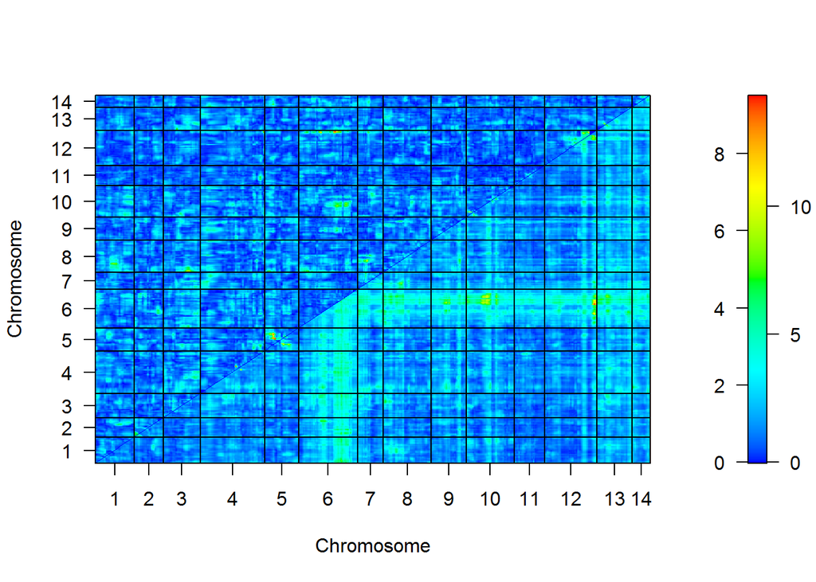

```r
plot(mimulus_scan2)
```

Também foram calculados as “penalidades” de LOD Scores para o threshold pelos seguintes comandos:

```r
#mimulus_scan = scantwo(mimulus_gp, pheno.col=6, method = "hk",
#               verbose = TRUE, n.perm = 1000)

#save(mimulus_scan, file="mimulus_scan.RData")

load("mimulus_scan.RData")
pen = calc.penalties(mimulus_scan, alpha=c(0.1))
```

Após obter os valores das “penalidades”, o mapeamento por múltiplos intervalos foi realizado seguindo os seguintes comandos:

$OBS_1$: Utilizou-se a função **stepwiseqtl** que executa seleção forward/backward para identificar um modelo de múltiplos QTLs, com auxílio de thresholds de LODs penalizados, com penalidades distintas sobre os efeitos principais e efeitos de interações;

$OBS_2$: Como início, foi testado um máximo de 10 QTLs a serem procurados no genoma.

```r
#MIM - automático
mimulus_mim = stepwiseqtl(mimulus_gp,pheno.col=6, max.qtl = 10,
                      penalties = pen, method = "hk" , additive.only= FALSE,
                      verbose = TRUE, keeplodprofile=TRUE,
                      keeptrace=TRUE )
```

```
##  -Initial scan
## initial lod:  4.231263
## ** new best ** (pLOD increased by 0.8181)
##     no.qtl =  1   pLOD = 0.818085   formula: y ~ Q1
##  -Step 1
##  ---Scanning for additive qtl
##         plod = -0.3936439
##  ---Scanning for QTL interacting with Q1
##         plod = -11.4525
##  ---Refining positions
##     no.qtl =  2   pLOD = -0.3936439   formula: y ~ Q1 + Q2
##  -Step 2
##  ---Scanning for additive qtl
##         plod = -2.043828
##  ---Scanning for QTL interacting with Q1
##         plod = -11.72095
##  ---Scanning for QTL interacting with Q2
##         plod = -12.94412
##  ---Look for additional interactions
##         plod = -14.19969
##  ---Refining positions
##  ---  Moved a bit
##     no.qtl =  3   pLOD = -2.002911   formula: y ~ Q1 + Q2 + Q3
##  -Step 3
##  ---Scanning for additive qtl
##         plod = -3.574432
##  ---Scanning for QTL interacting with Q1
##         plod = -14.03855
##  ---Scanning for QTL interacting with Q2
##         plod = -14.82606
##  ---Scanning for QTL interacting with Q3
##         plod = -15.18468
##  ---Look for additional interactions
##         plod = -15.71105
##  ---Refining positions
##  ---  Moved a bit
##     no.qtl =  4   pLOD = -3.35591   formula: y ~ Q1 + Q2 + Q3 + Q4
##  -Step 4
##  ---Scanning for additive qtl
##         plod = -4.64712
```

[output cut: 144 more lines]

```
##  ---Refining positions
##  ---  Moved a bit
##  ---Dropping Q2
##     no.qtl =  3   pLOD = -1.995654   formula: y ~ Q1 + Q2 + Q3
##  ---Refining positions
##  ---Dropping Q2
##     no.qtl =  2   pLOD = -0.8154405   formula: y ~ Q1 + Q2
##  ---Refining positions
##  ---  Moved a bit
##  ---Dropping Q2
##     no.qtl =  1   pLOD = 0.7821799   formula: y ~ Q1
##  ---Refining positions
##  ---  Moved a bit
## ** new best ** (pLOD increased by 0)
##  ---One last pass through refineqtl
```

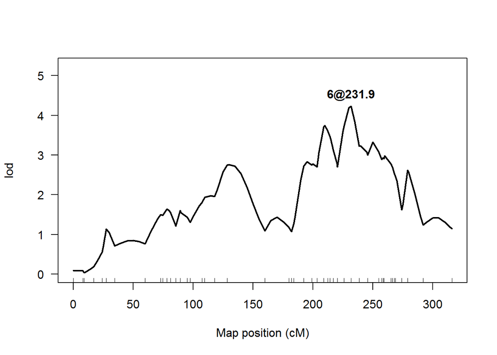

```r
plotLodProfile(mimulus_mim)
```

```r
summary(mimulus_mim)
```

```
##   QTL object containing genotype probabilities.
##
##       name chr    pos n.gen
## Q1 6@231.9   6 231.85     3
##
##   Formula: y ~ Q1
##
##   pLOD:  0.818
```

Pelos resultados do MIM há evidência de um único QTL com efeito sobre a característica fenotípica **pa** (phe 6). O modelo resultante do MIM foi: **Y ~ Q1**.

Para encontrar os efeitos do QTL em questão, foi utilizado os seguintes comandos:

```r
##Montando o QTL
qtl_rf=makeqtl(mimulus_gp, chr=c(6), pos=c(231.85), what="prob")


#Efeitos do QTL
efeitos = fitqtl(mimulus_gp, qtl = qtl_rf, method="hk", pheno.col=6, get.ests=TRUE)
summary(efeitos)
```

```
##
##      fitqtl summary
##
## Method: Haley-Knott regression
## Model:  normal phenotype
## Number of observations : 252
##
## Full model result
## ----------------------------------
## Model formula: y ~ Q1
##
##        df        SS        MS      LOD     %var Pvalue(Chi2)    Pvalue(F)
## Model   2  10.88855 5.4442748 4.231262 7.441022 5.871344e-05 6.593404e-05
## Error 249 135.44283 0.5439471
## Total 251 146.33138
##
##
## Estimated effects:
## -----------------
##                 est        SE      t
## Intercept  0.624916  0.046866 13.334
## 6@231.9a  -0.305240  0.068738 -4.441
## 6@231.9d  -0.003653  0.095180 -0.038
```

```r
n=282
LOD2=4.2312
r21=1-10^(((-2)/n)*LOD2)
r21
```

```
## [1] 0.06676399
```

#### 1.3.3.1 Resultado do MIM - fenótipo pa (phe 6)

O mapeamento por múltiplos intervalos (MIM) encontrou um QTL com efeito significativo sobre a característica fenotípica **pa** (phe 6). O resultado do mapeamento MIM foi resumido na Tabela abaixo (contendo o nome do QTL, o cromossomo que o contêm, a posição no cromossomo, o valor do intercepto da regressão, os valores dos efeito do QTL (aditivo e de dominância), o LOD e o $R^2$:

Sabe-se que o MIM permite estudos de interação entre os efeitos de diferentes QTLs (utilizando a Tabela de interação de Cockerham), mas para o fenótipo em questão foi apenas encontrado 1 QTL pelo métodos MIM.

| QTL | Cromossomo | Posição (cM) | Intercepto | Ef. aditivo | Ef. de dominância | LOD | $R^2$ | p-valor |
| --- | --- | --- | --- | --- | --- | --- | --- | --- |
| Q1 | 6 | 231.9 | 0,625 | -0,305 | -0,00365 | 4,231 | 0,067 | 0,0000659 |

O QTL em quetão também pode ser observado no gráfico:

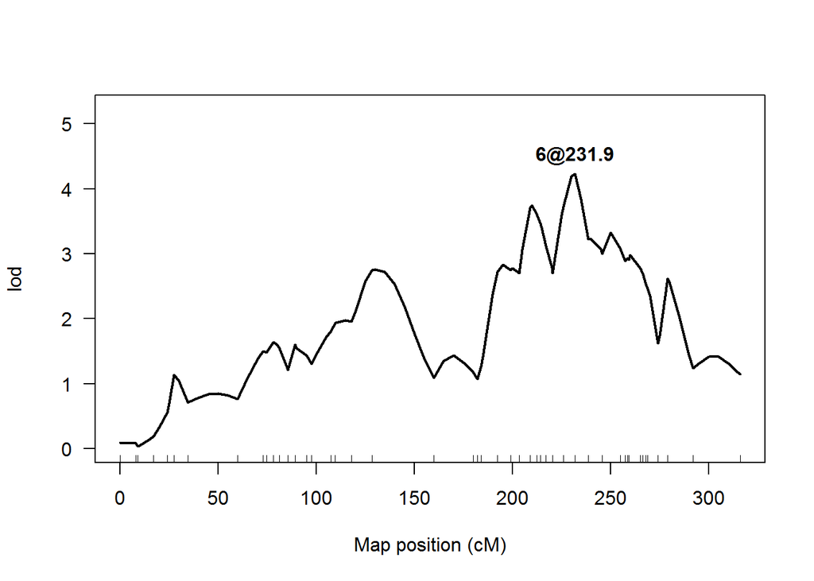

```r
plotLodProfile(mimulus_mim)
```

## 1.4 Característica fenotípica phe 1 (fl)

### 1.4.1 Nível de significância (“Threshold”)

Primeiramente foi calculado o nível de significância (LOD) para declarar como significativo o efeito dos QTLs (“Threshold”).

Para isso, criou-se a distribuição de LODs sob $H_0$ utilizado os seguintes comandos:

$OBS_1$: foi utilizado a aproximação de Haley-Knott (“hk”) no cálculo das permutações;

$OBS_2$: foram realizadas 1000 permutações.

```r
#Significância - "uso de permutações"
mimulus_gp2 = calc.genoprob(mimulus, step = 1)
sig_perm2 = scanone(mimulus_gp2, method = "hk", pheno.col=1, n.perm=1000, tol=1e-4)
```

```
## Doing permutation in batch mode ...
```

Foram obtidos os valores do threshold (LOD) para 5% (alpha) de significância:

```r
summary(sig_perm2, alpha=c(0.05))
```

```
## LOD thresholds (1000 permutations)
##    lod
## 5% 3.8
```

E o gráfico da distribuição da estastística (LOD) sob $H_0$:

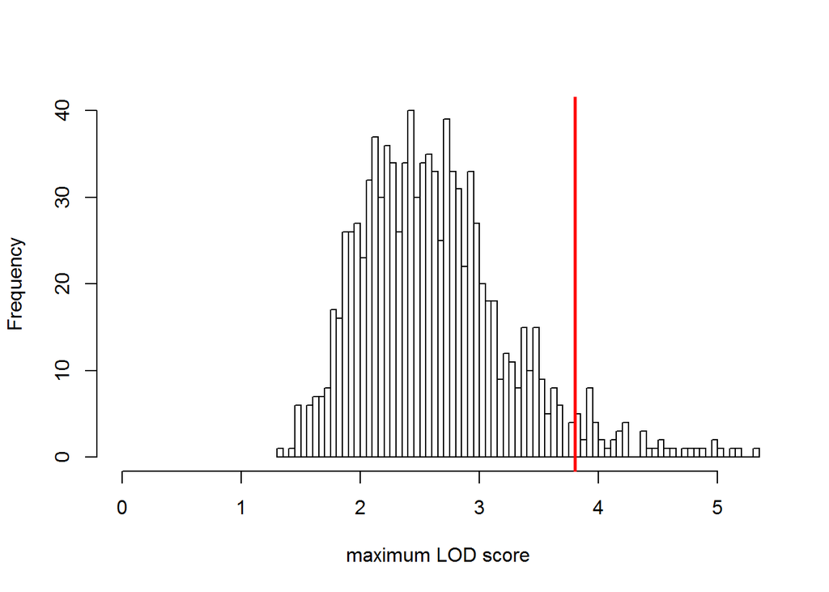

```r
plot(sig_perm2)
abline(v=3.8, col="red", lwd=2.5)
```

### 1.4.2 Mapeamento por intervalo composto (CIM)

O mapeamento por intervalo composto pode ser realizado de acordo com os comando abaixo:

$OBS_1$: foi utilizado o algoritmo **“EM”**;

$OBS_2$: foi utilizado uma **window size = 10 cM**;

$OBS_3$: foi utilizado um **threshold = 3.8** (cálculo por permutação)

```r
# Mapeamento - intervalo composto (CIM)
mimulus_cim2 = cim(mimulus_gp2, pheno.col=1, window=10,
                   method = "em", n.marcovar=1)
summary(mimulus_cim2)
```

```
##            chr   pos   lod
## c1.loc61     1  61.0 0.698
## c2.loc107    2 107.0 2.644
## BD292        3  32.1 2.306
## MgSTS455     4 132.1 2.934
## c5.loc11     5  11.0 1.173
## MgSTS542A    6  27.6 0.885
## MgSTS34      7  73.3 0.554
## AAT296       8 166.2 2.285
## BB176        9  89.5 2.287
## AAT374      10 157.5 4.898
## c11.loc158  11 158.0 3.199
## c12.loc11   12  11.0 0.934
## c13.loc135  13 135.0 1.536
## c14.loc45   14  45.0 3.003
```

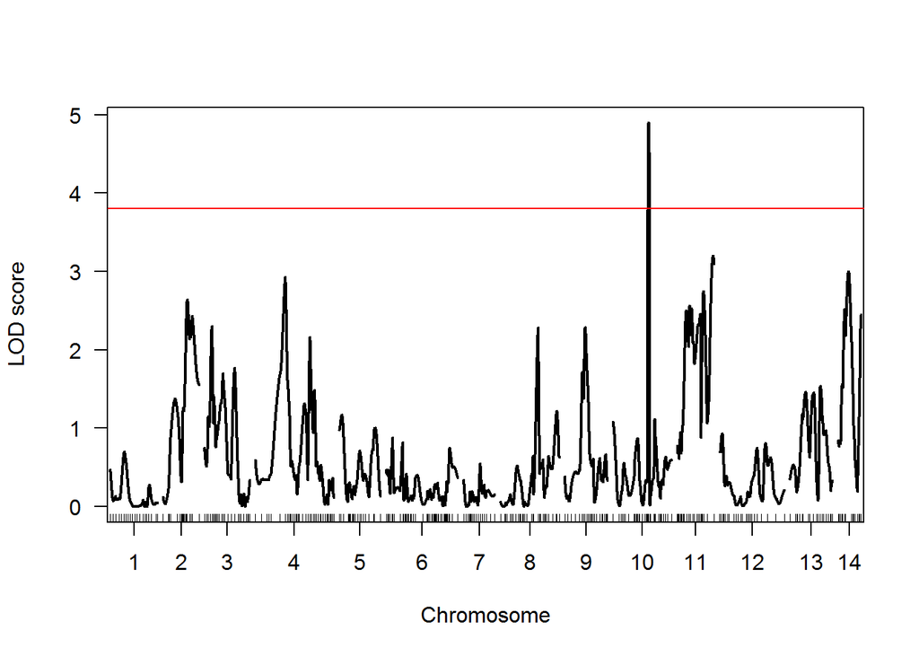

```r
plot(mimulus_cim2, ylab="LOD score")
abline(h = 3.8, col="red") #5%
```

No gráfico é observado que, para a característica fenotípica **fl** (phe 1), há evidências de um QTL, com LOD acima do threshold (LOD = 3.8), no grupo de ligação 10 (cromossomo 10) na posição **157.5 cM** .

Pelos comandos abaixo é possível observar em detalhes o grupo de ligação 10:

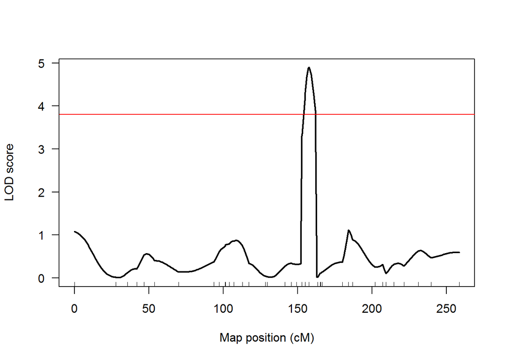

```r
plot(mimulus_cim2, ylab="LOD score", chr=c(10))
abline(h = 3.8, col="red") #5%
```

Para encontrar os efeitos do QTL em questão, foi utilizado os seguintes comandos:

```r
#Efeito do QTL
mimulus_qtl_cim2 = makeqtl(mimulus_gp2, chr=c(10), pos=c(157.5), what="prob")
qtl_cim_16 = fitqtl(mimulus_gp2, qtl = mimulus_qtl_cim2,
                  method="hk", pheno.col=1, get.ests=TRUE)
summary(qtl_cim_16)
```

```
##
##      fitqtl summary
##
## Method: Haley-Knott regression
## Model:  normal phenotype
## Number of observations : 276
##
## Full model result
## ----------------------------------
## Model formula: y ~ Q1
##
##        df        SS         MS      LOD     %var Pvalue(Chi2)    Pvalue(F)
## Model   2  201.5191 100.759526 4.908853 7.864159 1.233523e-05 1.394776e-05
## Error 273 2360.9806   8.648281
## Total 275 2562.4997
##
##
## Estimated effects:
## -----------------
##               est      SE       t
## Intercept 20.1867  0.1777 113.615
## 10@157.5a  1.2558  0.2618   4.796
## 10@157.5d  0.2504  0.3559   0.704
```

```r
n=282
LOD1=4.91
r21=1-10^(((-2)/n)*LOD1)
r21
```

```
## [1] 0.07705185
```

#### 1.4.2.1 Resultado do CIM - fenótipo fl (phe 1)

Pelo método do mapeamento por intervalo composto (CIM) foi encontrado um QTL com efeito significativo sobre o fenótipo **fl** (phe 1).O resultado do mapeamento CIM foi resumido na Tabela abaixo (contendo o nome do QTL, o cromossomo que o contêm, a posição no cromossomo, o valor do intercepto da regressão, os valores dos efeito do QTL (aditivo e de dominância), o LOD e o $R^2$:

| QTL | Cromossomo | Posição (cM) | Intercepto | Ef. aditivo | Ef. de dominância | LOD | $R^2$ | p-valor |
| --- | --- | --- | --- | --- | --- | --- | --- | --- |
| Q1 | 10 | 157,5 | 20,187 | 1,256 | 0,25 | 4,91 | 0,077 | $1,39.10^{-5}$ |

E também no gráfico:

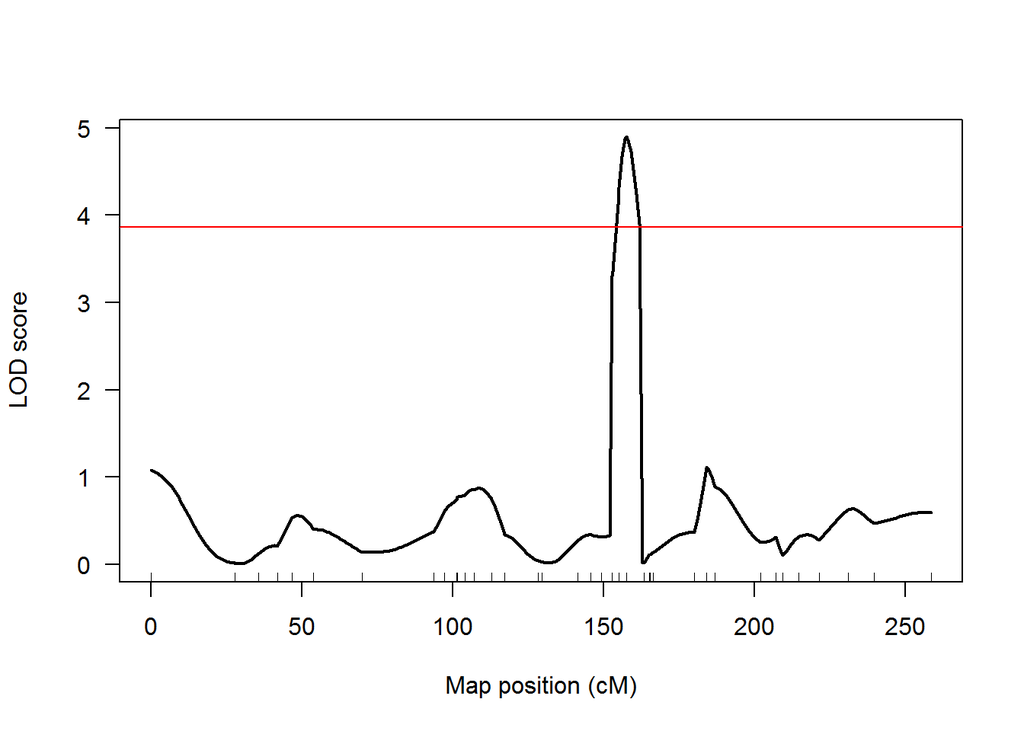

```r
plot(mimulus_cim2, ylab="LOD score", chr=c(10))
abline(h = 3.86, col="red") #5%
```

### 1.4.3 Mapeamento por múltiplos intervalos - (MIM)

Primeiramente usou-se a função **scantwo** para escanear o genoma a procura de mais de um QTL.

```r
##Mapeamento - múltiplos intervalos (MIM)
mimulus_gp = calc.genoprob(mimulus, step = 10, error.prob=0.001)
mimulus_scan2 = scantwo(mimulus_gp,pheno.col=1, model="normal", method="hk",
                               use="all.obs", verbose=TRUE)
```

[output not shown]

[output cut: 52 more lines]

[output not shown]

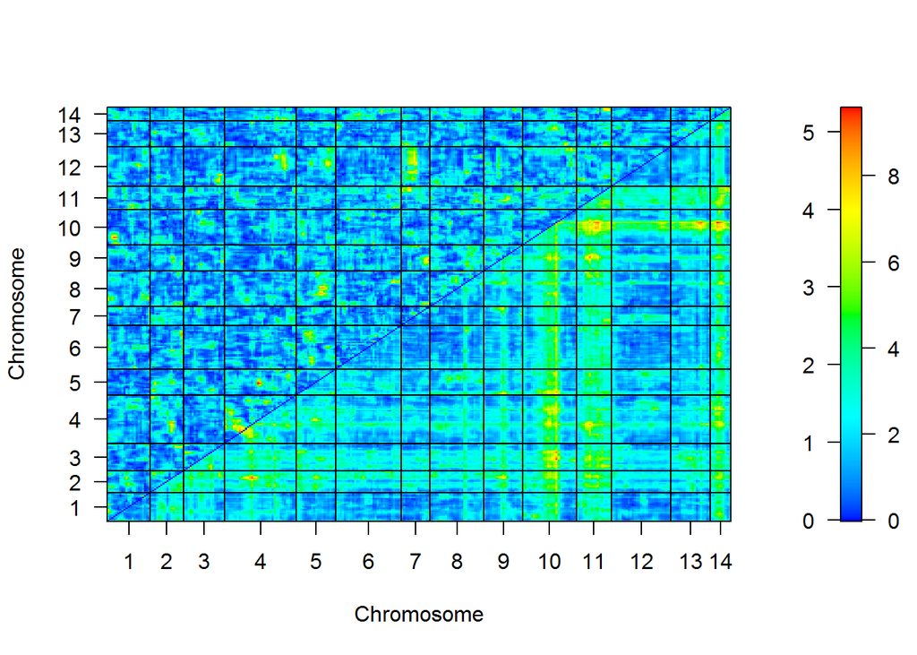

```r
plot(mimulus_scan2)
```

Também foram calculados as “penalidades” de LOD Scores para o threshold pelos seguintes comandos:

```r
#mimulus_scan1 = scantwo(mimulus_gp, pheno.col=1, method = "hk",
#               verbose = TRUE, n.perm = 1000)

#save(mimulus_scan1, file="mimulus_scan1.RData")

load("mimulus_scan1.RData")
pen = calc.penalties(mimulus_scan1, alpha=c(0.10))
```

Após obter os valores das “penalidades”, o mapeamento por múltiplos intervalos foi realizado seguindo os seguintes comandos:

$OBS_1$: Utilizou-se a função **stepwiseqtl** que executa seleção forward/backward para identificar um modelo de múltiplos QTLs, com auxílio de thresholds de LODs penalizados, com penalidades distintas sobre os efeitos principais e efeitos de interações.